# 2_analysis

## Data

Google My Business search results were collected for 4 unique keyword combinations in 426 US cities, giving in total 1659 search results. The format of the search queries was one the following:

- (city) + " car accident lawyer"
- (city) + " personal injury lawyer"
- (city) + " car accident attorney"
- (city) + " personal injury attorney"

#### Independent variables

All variables with prefix “Relative” are calculated as rank(values) / length(values) for values inside each search group. So for example, search with keyword “Milwaukee car accident lawyer” the entry with highest number of photos would get Relative number of photos value equal to 1, entry with lowest value would get 0, and the rest of the values would be something in between. The motivation behind this transformation is to make attribute values more comparable between searches, i.e. trying to minimize effect of the size of the population of the city etc.

- Attributes from basic.csv
  - Review rating
  - Relative # of reviews
  - Relative # of photos
  - Relative # of questions
  - Provides updates
  - Is business claimed
  - Has street address
  - Has website
  - Has phone
  - #Keywords in description
  - #Keywords in title
  - Has city in description
  - Has city in title
  - Has lawyer or attorney in title
  - Has lawyer or attorney in description
  - Has car in description
  - Has car in title
  - Has injury in description
  - Has injury in title
  - #Characters in description
  - #Characters in title
  - Type category is personal injury attorney
  - Type category is lawyer
  - Type category is law firm
  - Type category is empty
  - Type category is criminal justice attorney
  - Type category is other
- Attributes from social_profile.csv
  - Has twitter
  - Has fb
  - Has youtube
  - Has instagram
  - Has linkedin
- Attributes from all_reviews.csv
  - Ratio of 5s in ratings
  - Ratio of 4s in ratings
  - Ratio of 3s in ratings
  - Ratio of 2s in ratings
  - Ratio of 1s in ratings
  - Review response ratio
  - Relative # of review likes
- Attributes from q_a.csv
  - Question answer ratio
- Attributes from backlink_data_websites.csv
  - Relative domain_rating
  - Relative ahrefs_rank
  - Relative ref_domains_total
  - Relative ref_domains_dofollow
  - Relative linked_domains
  - Relative total_backlinks
  - Relative backlinks_no_follow
  - Relative total_keywords
  - Relative total_traffic

#### Dependent variables

- Position in the search results

```
## [1] "/home/sherlock/Files/R/2020-GMB-study/raw_data/GMB data/basic.csv"
```

## Modelling

The goal of the statistical modelling in this study is to find answers to three key questions:

1. How accurately can the rankings be predicted given the dependent variables?
2. What are the most important features for the predictions?
3. What is the direction of the impact?

The method of choice for the study was gradient boosted decision trees (GBDT). GBDT is a widely used machine learning technique which can be used in many settings from regression or classification to learning to rank type of problems. In a learning to rank problem, there is a ordered list of items and the goal for the model is to calculate a score for each item based on dependent variables such that the original order is retained.

In process of building the model, data set was split to two folds: train data (containing around 70% of searches) and test data (the rest of the data, about 30%). GBDT model was fitted using training data, predictions were calculated for the test data set, and then finally predictions were compared to real observed rankings. The chosen evaluation metric was Spearman’s rank correlation coefficient. Spearman’s rank correlation is a scaled measurement of the agreement of two rankings. Perfectly matching rankings would give value of 1, the expected value for random rankings is zero and reverse order would have value of -1.

The next step is to understand why the model makes particular predictions; what are the most important dependent variables and how their values effect the predictions? For this purpose SHapley Additive exPlanations (SHAP) values were calculated. In SHAP each prediction is presented as a sum of each dependent variable’s responsibility. Then the overall impact of any particular variable can be measured as a average of absolute values over the whole data set.

## Results

#### Accuracy

- In the plot below, showing the distribution of correlations calculated separately for each search
- Overall mean correlation is about 0.6, showing fairly good fit between observations and predictions

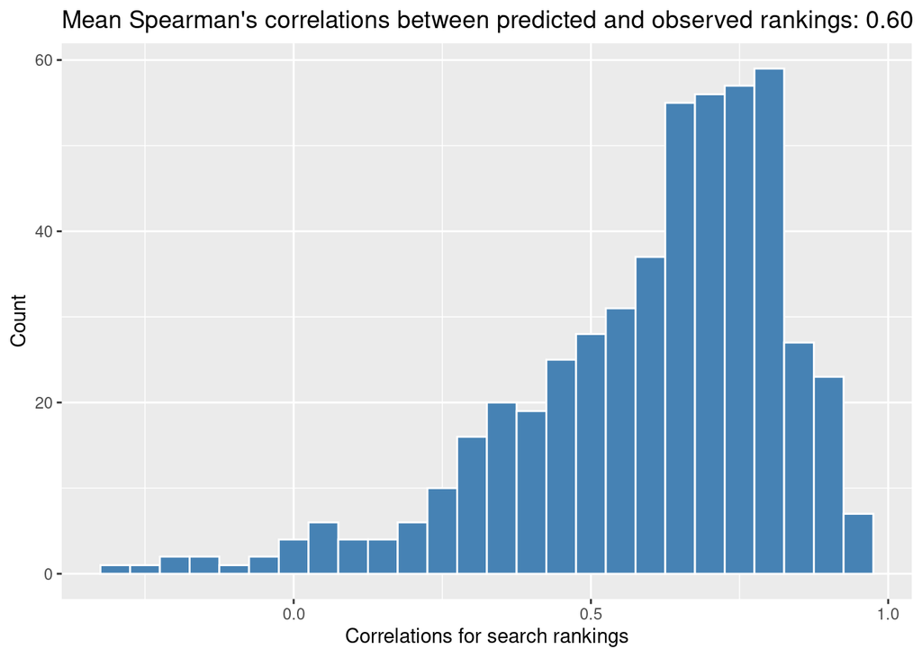

### Feature importance

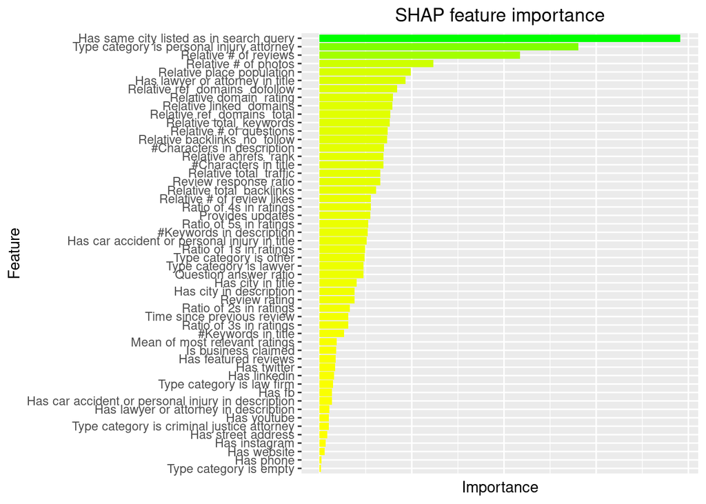

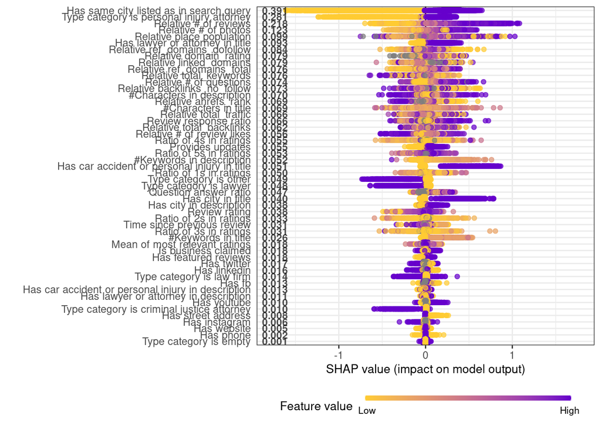

## A closer look at the features

The depended variables used in this study can be roughly organized into five main groups, these are listed below and also showing a few important variables suggested by SHAP values.

- Location
  - Has same city listed as in search query
  - Relative place population
- Popularity
  - Relative # of photos
  - Relative # of questions
- Type category
  - Type category is personal injury attorney/lawyer
- Keywords and title/description
  - Has “lawyer or attorney”/city in title
  - #Characters in description
- Reviews
  - Relative # of reviews
  - Review rating

In terms of SEO, the first two categories are not much of a interest as they are something difficult or even impossible to change or adjust, but the last three are more interesting and worth further investigation.

### Type category

Basic information about type categories

| Type | Value |
| --- | --- |
| Total unique categories | 72 |
| Missing type category | 1.99% |
| Categories with more than >=10 results | 26 |
| Categories with more than >=100 results | 13 |
| Categories with more than >=1000 results | 3 |
| Median unique categories in one search | 4 |
| Min unique categories in one search | 1 |
| Max unique categories in one search | 12 |

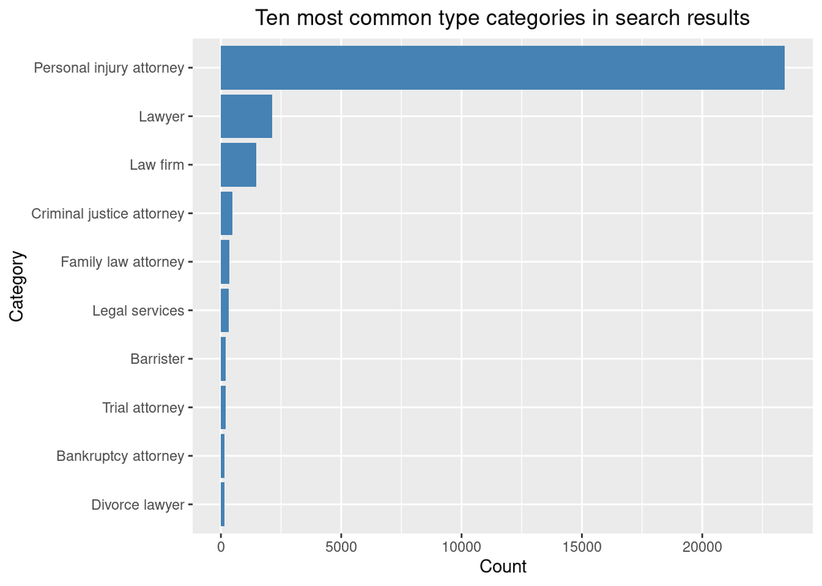

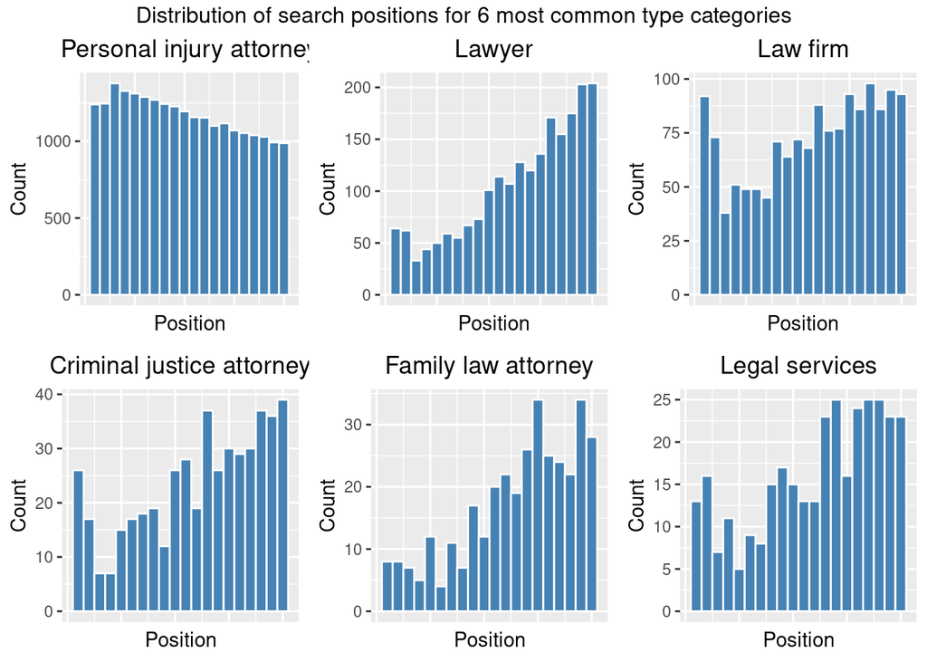

Key takeaways:

- Distributions for more general categories (Lawyer, Law firm, Legal services) are tilted towards lower positions in the results compared to best matching category (Personal injury attorney).
- Same thing occurs with specific, but less matching categories (Criminal justice attorney, Family law attorney)
- However, some of these categories (Law firm, Criminal justice attorney, Legal services) have relatively large counts for top positions. One possible explanation is that these groups represent larger companies with high revenues and therefore would be ranked higher.

### Titles and descriptions

Basic information about titles and descriptions

| Type | Title | Description |
| --- | --- | --- |
| Median character length (non missing) | 24 | 534 |
| Min character length (non missing) | 4 | 8 |
| Max character length (non missing) | 125 | 752 |
| Missing | 0.01% | 40.66% |
| Containing lawyer or attorney | 22.65% | 43.62% |
| Containing car accident or personal injury | 5.32% | 44.76% |
| Containing city name | 5% | 27.07% |

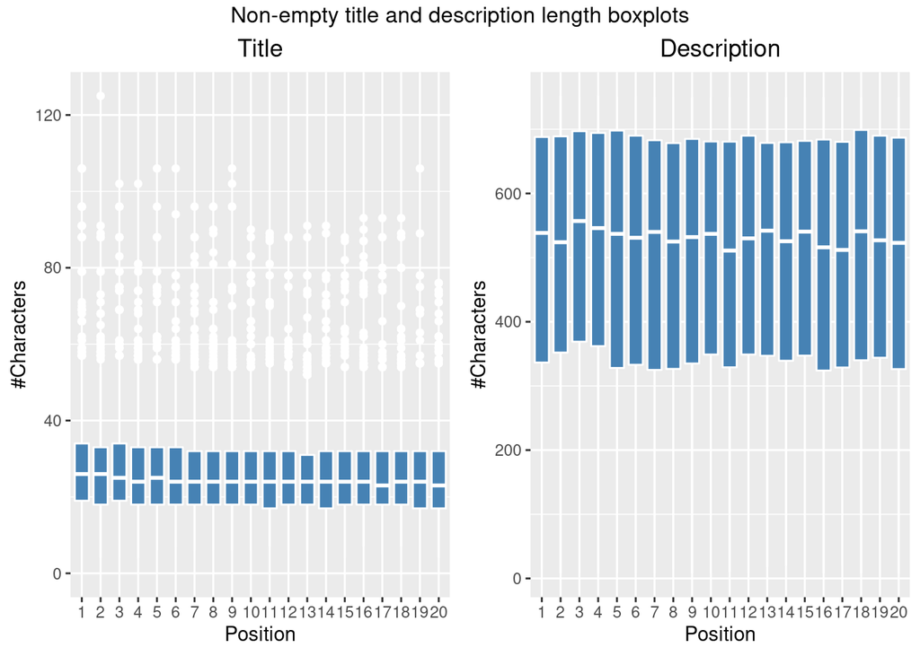

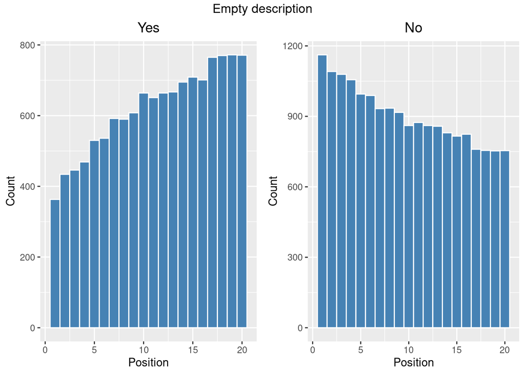

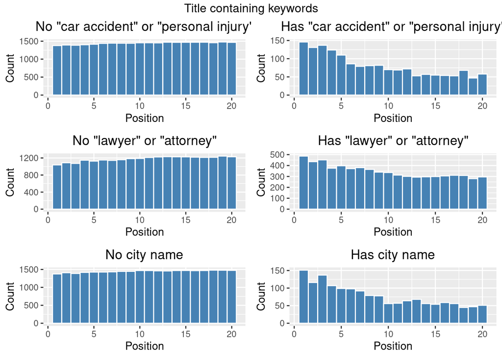

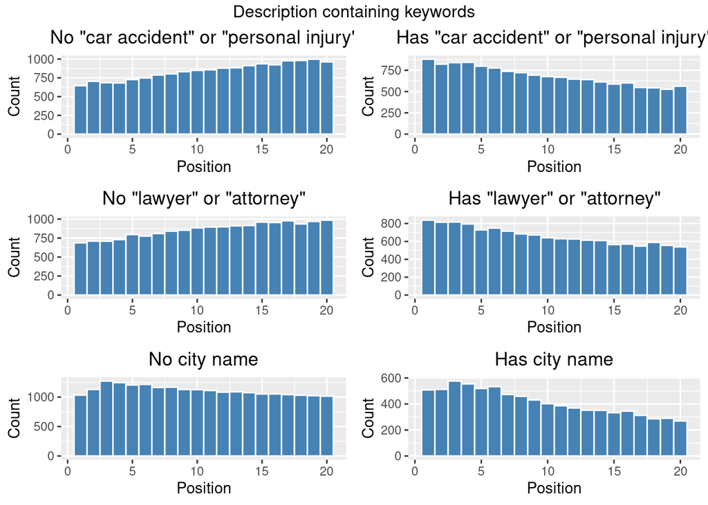

### Reviews

Basic information about reviews

| Type | Value |
| --- | --- |
| Median #reviews | 14 |
| Max #reviews | 968 |
| No reviews available | 16.57% |
| Average rating | 4.61 |
| Response ratio by owners | 33.43% |
| Average number of likes per review | 0.66 |

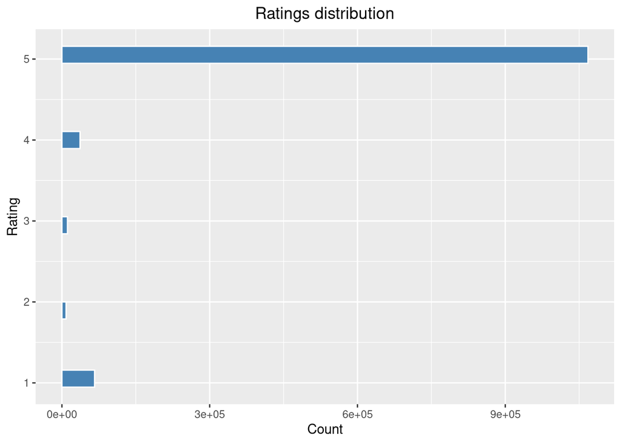

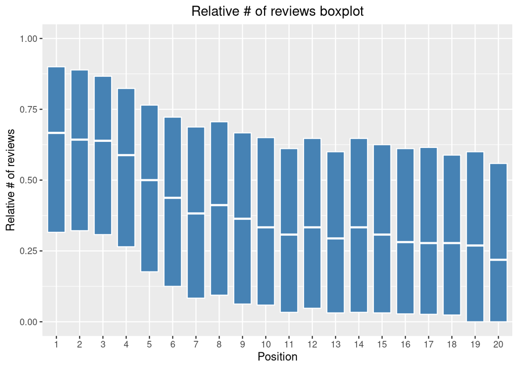

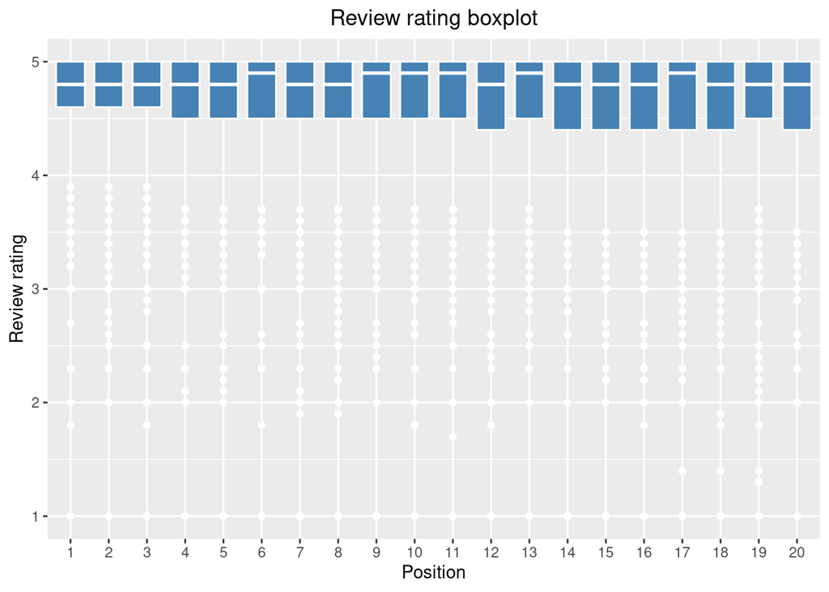

[figure not shown]

Key takeaways:

- Businesses with highest number of reviews tend to have the lowest positions (top left corner)
- In contrast, low number of reviews correlates with higher position (bottom right)
- Perhaps surprisingly, ratings themself don’t seem to practically any effect on page’s position, only activity matters.
- But then on the other hand, if almost 90% of ratings are five stars and average rating is over 4.5, maybe there just isn’t much room for a differentiation.

### Backlink

Basic information about backlinks

| Type | ref_domains_dofollow | total_traffic | ahrefs_rank | domain_rating |
| --- | --- | --- | --- | --- |
| Median | 40 | 82 | 17841948 | 10 |
| Min | 0 | 0 | 4281 | 0 |
| Max | 13379 | 3444072 | 171527697 | 85 |
| Missing | 0.36% | 0.36% | 0.43% | 0.43% |

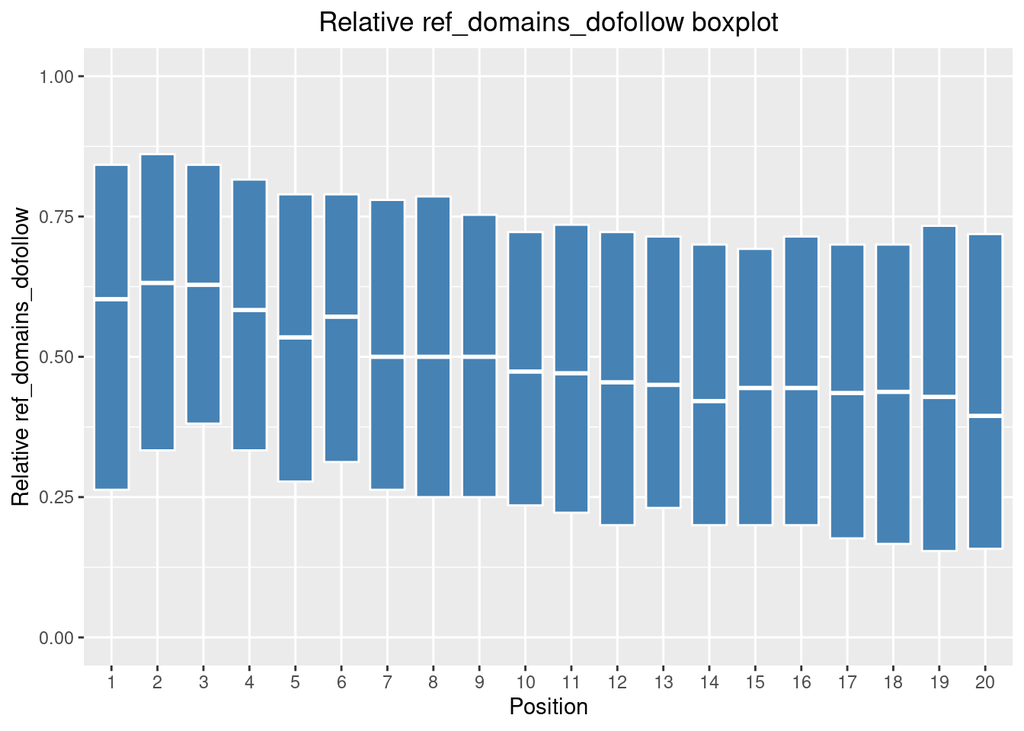

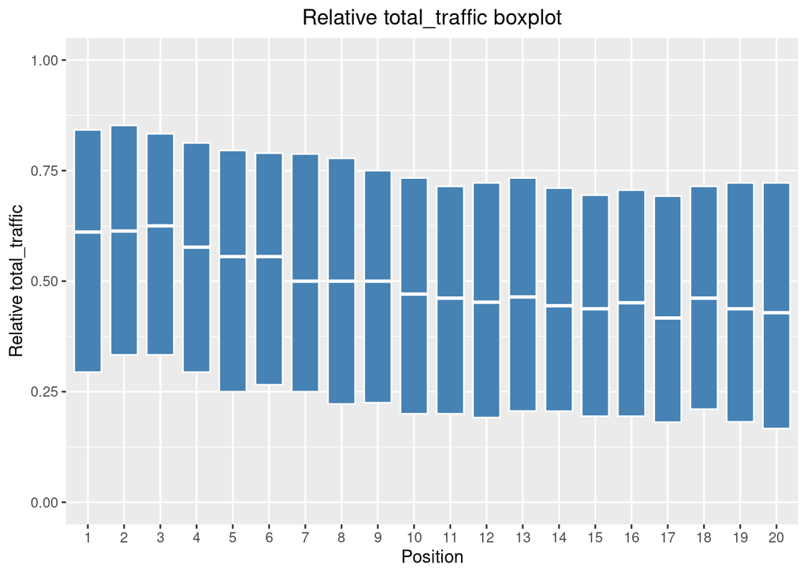

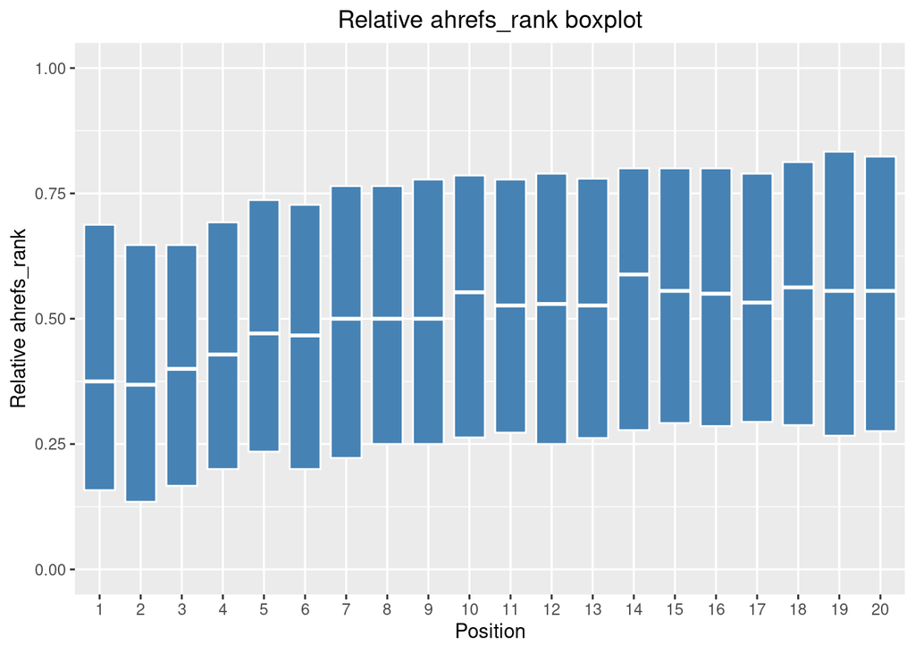

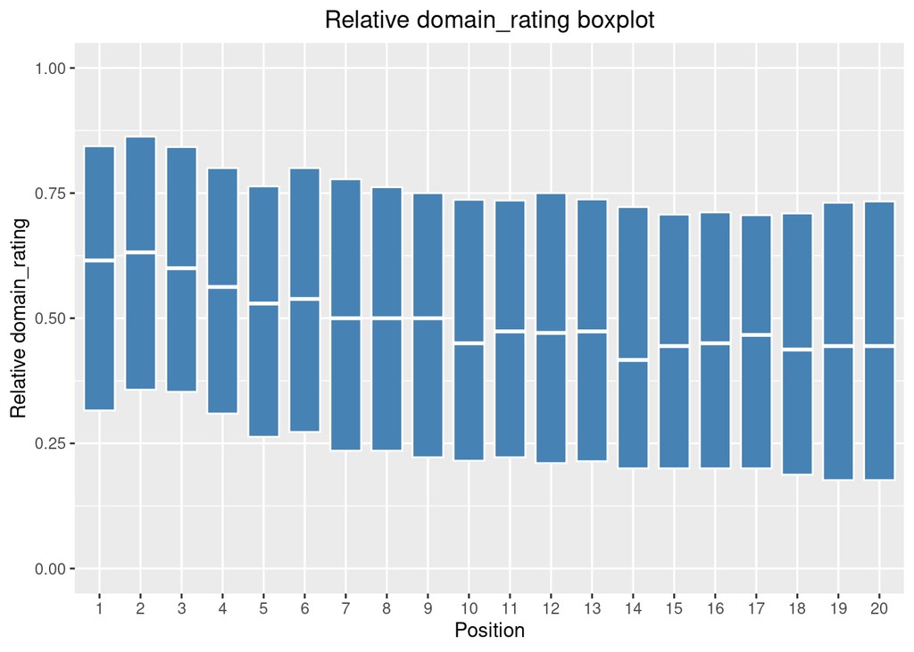

Key takeaways:

- Higher ref_domains_dofollow and total_traffic are more common for better positions
- ahrefs_rank seems to be telling the same story, the only difference is that small number for rank is better, so the shape is inverted

Basic information about #photos and Google updates

| Type | Value |
| --- | --- |
| Median #photos | 6 |
| Max #photos | 540 |
| Zero #photos | 5.77% |
| Provides Google updates | 54.83% |

### Provided updates and #photos

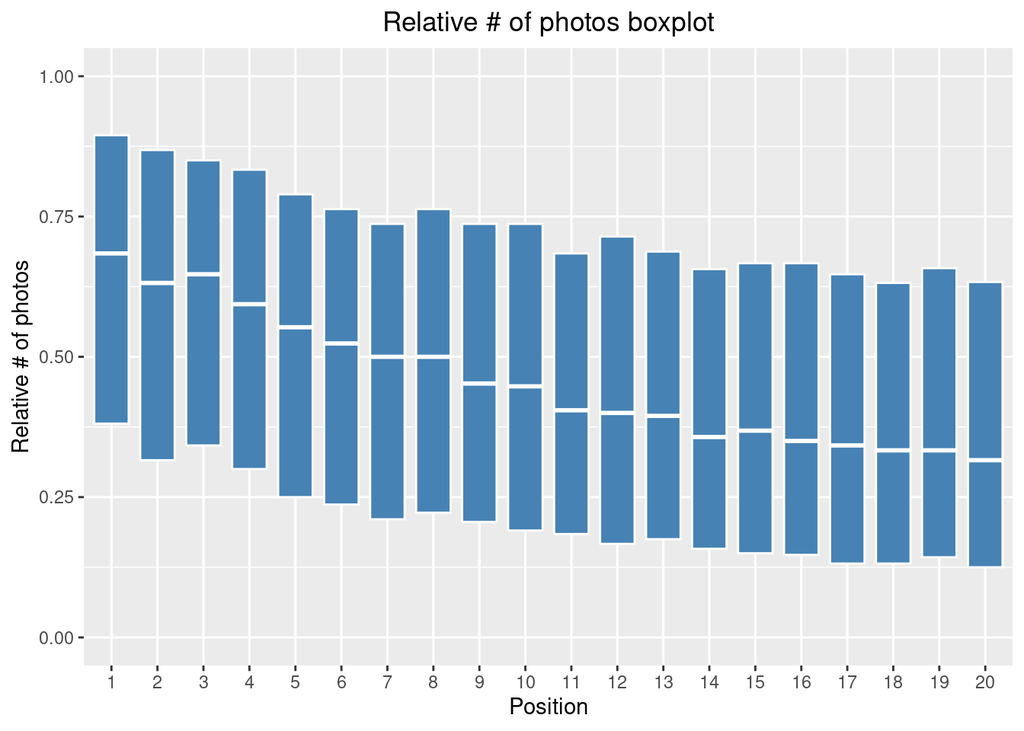

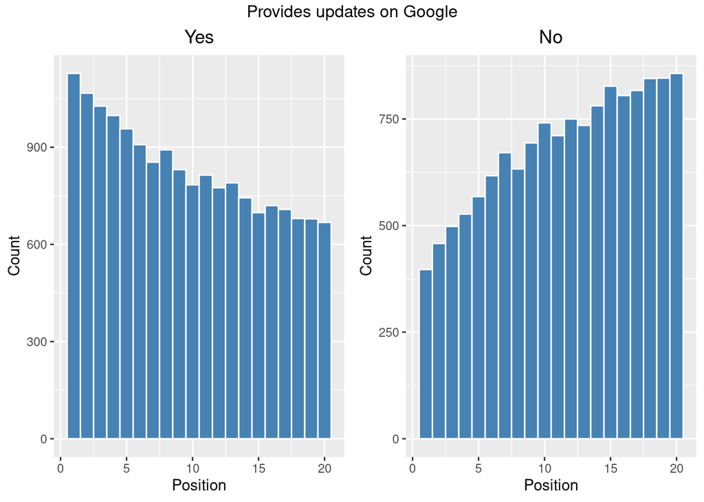

Key takeaways:

- Businesses who provide Google updates more often tend to have better positions.
- Similarly, also higher number of photos is correlated with better positions.
- So once again, activity seems to be the key